# Aljabi_Didwania_Assignment2

## Assignment 2:

### Each problem is independent and should run without the need of the previous one to run!

### Question 6.3 Multilinear Regression

The following problem takes place in the United States in the late 1990s, when many major US cities were facing issues with airport congestion, partly as a result of the 1978 deregulation of airlines. Both fares and routes were freed from regulation, and low-fare carriers such as Southwest (SW) began competing on existing routes and starting nonstop service on routes that previously lacked it. Building completely new airports is generally not feasible, but sometimes decommissioned military bases or smaller municipal airports can be reconfigured as regional or larger commercial airports. There are numerous players and interests involved in the issue (airlines, city, state and federal authorities, civic groups, the military, airport operators), and an aviation consulting firm is seeking advisory contracts with these players. **The firm needs predictive models to support its consulting service. One thing the firm might want to be able to predict is fares, in the event a new airport is brought into service.** The firm starts with the file Airfares.csv, which contains real data that were collected between Q3—1996 and Q2—1997. The variables in these data are listed in Table 6.13, and are believed to be important in predicting FARE. Some airport-to-airport data are available, but most data are at the city-to-city level. One question that will be of interest in the analysis is the effect that the presence or absence of **Southwest has on FARE.**

#### **a. Explore** the numerical predictors and outcome (FARE) by creating a correlation table and examining some scatterplots between FARE and those predictors. What seems to be the best single predictor of FARE?

*The distance and the Coupon (number of stops) seem to have good correlations with FARE and can be used as predictors. Average income in both starting and ending city have modest correlations with the FARE, and the population are as well*

```python
# Importing important packages
import pandas as pd
import matplotlib.pyplot as plt
import matplotlib.lines as mlines

from sklearn.model_selection import train_test_split
from sklearn.linear_model import LinearRegression
import scikitplot as skplt

from dmba import regressionSummary, exhaustive_search
from dmba import backward_elimination, forward_selection, stepwise_selection
from dmba import adjusted_r2_score, AIC_score, BIC_score
```

```python
# Reading the file:
df = pd.read_csv('./datasets/Airfares.csv')
df.drop(['S_CODE', 'S_CITY', 'E_CODE', 'E_CITY'],axis=1,inplace=True)

# Separating Numerical and Categorical predictors
num_preds = ['COUPON','HI','S_INCOME','E_INCOME','S_POP','E_POP','DISTANCE','PAX','FARE']
categ_preds = ['VACATION','SW','SLOT','GATE','NEW','FARE']

num_df = df[numerical_preds]
categ_df = df[categ_preds]
```

```python
# Correlation table between the airline FARE and the other numerical vars
print('FARE Correlation Table\n')
print(num_df.corr()['FARE'])
```

[output not shown]

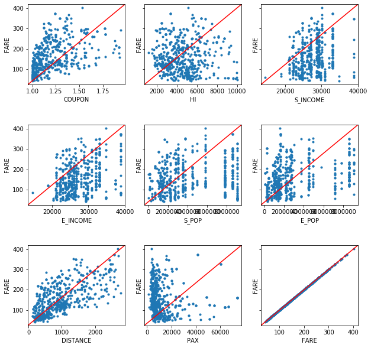

```python
# Plotting all numerical variables with FARE to see which one can be the best predictor.
#   I created a figure of 9 subplots and then looped through the data to plot them

fig, ax = plt.subplots(3, 3, sharey='row', figsize = [10,10])
plt.subplots_adjust(hspace=.5, wspace=0.2)

# Coordinates inside the fig
coords = [(i,j) for i in range(3) for j in range(3)]



i = 0
for pred in num_preds:

    ax[coords[i]].plot(num_df[pred],num_df['FARE'],'.')
    ax[coords[i]].set_xlabel(pred)
    ax[coords[i]].set_ylabel('FARE')

    # Adding a 45 degree line to use as reference
    line = mlines.Line2D([0, 1], [0, 1], color='red')
    transform = ax[coords[i]].transAxes
    line.set_transform(transform)
    ax[coords[i]].add_line(line)

    i+=1
```

#### **b. Explore** the categorical predictors (excluding the first four) by computing the percentage of flights in each category. Create a pivot table with the average fare in each category. Which categorical predictor seems best for predicting FARE

*Having a SW seems to be a very good predictor because the prices decreas significantly when SW is available for the route. Additionally, both SLOT and GATE predictors seem to have some effect as when both are constrained, the prices jump high.*

```python
# Creating a dictionary that has summarized data from the dataframe for only categorical predictors.
#   Then printing the pivot tables with the summaries for each predictor.
dic_of_categs = {}

# looping over the data, summarizing it.
for categ in categ_preds:
    if categ != 'FARE':
        dic_of_categs[categ] = {}
        for uniq in set(categ_df[categ]):
            dic_of_categs[categ][uniq] = {}
            dic_of_categs[categ][uniq]['Count'] = categ_df.query('{} == "{}"'.format(categ,uniq))[categ].count()
            dic_of_categs[categ][uniq]['Percentage'] = categ_df.query('{} == "{}"'.format(categ,uniq))[categ].count()/len(df)
            dic_of_categs[categ][uniq]['Average of Fare'] = categ_df.query('{} == "{}"'.format(categ,uniq))['FARE'].mean()

# looping over the dictionary and printing it.
for key in dic_of_categs:
    print('\n\n',key)
    print(pd.DataFrame(dic_of_categs[key]))
```

```
 VACATION
                         No         Yes
Count            468.000000  170.000000
Percentage         0.733542    0.266458
Average of Fare  173.552500  125.980882


 SW
                         No         Yes
Count            444.000000  194.000000
Percentage         0.695925    0.304075
Average of Fare  188.182793   98.382268


 SLOT
                       Free  Controlled
Count            456.000000  182.000000
Percentage         0.714734    0.285266
Average of Fare  150.825680  186.059396


 GATE
                       Free  Constrained
Count            514.000000   124.000000
Percentage         0.805643     0.194357
Average of Fare  153.095953   193.129032


 NEW
                          0           1           2           3
Count             34.000000   23.000000    9.000000  572.000000
Percentage         0.053292    0.036050    0.014107    0.896552
Average of Fare  123.161471  173.651304  147.688889  162.812325
```

#### **c. Find** a model for predicting the average fare on a new route. **each section will be commented below**.

```python
# i. Convert categorical variables into dummy variables.
#    Then, partition the data into training and validation sets.
#    The model will be fit to the training data and evaluated on the validation set.

num_preds = ['COUPON','HI','S_INCOME','E_INCOME','S_POP','E_POP','DISTANCE','PAX']
categ_preds = ['VACATION','SW','SLOT','GATE','NEW']
categ_df = categ_df.astype('str')

x = pd.get_dummies(categ_df[categ_preds[:len(categ_preds)]], drop_first=True)
x[num_preds] = df[num_preds]
y = df['FARE']

train_X, valid_X, train_y, valid_y = train_test_split(x, y, test_size=0.4, random_state=1)
```

```python
# ii. Use stepwise regression to reduce the number of predictors.
#    You can ignore the first four predictors (S_CODE, S_CITY, E_CODE, E_CITY).
#    Report the estimated model selected.

# TAKEN FROM THE CHAPTER NOTEBOOK
def train_model(variables):
    if len(variables) == 0:
        return None
    model = LinearRegression()
    model.fit(train_X[variables], train_y)
    return model

def score_model(model, variables):
    if len(variables) == 0:
        return AIC_score(train_y, [train_y.mean()] * len(train_y), model, df=1)
    return AIC_score(train_y, model.predict(train_X[variables]), model)

best_model, best_variables = stepwise_selection(train_X.columns, train_model, score_model, verbose=True)

print(best_variables)
```

```
Variables: VACATION_Yes, SW_Yes, SLOT_Free, GATE_Free, NEW_1, NEW_2, NEW_3, COUPON, HI, S_INCOME, E_INCOME, S_POP, E_POP, DISTANCE, PAX
Start: score=4379.42, constant
Step: score=4149.88, add DISTANCE
Step: score=4025.89, add SW_Yes
Step: score=3913.59, add VACATION_Yes
Step: score=3890.27, add HI
Step: score=3873.33, add GATE_Free
Step: score=3852.81, add SLOT_Free
Step: score=3850.30, add PAX
Step: score=3844.58, add E_POP
Step: score=3826.43, add S_POP
Step: score=3821.88, add E_INCOME
Step: score=3821.88, unchanged None
['DISTANCE', 'SW_Yes', 'VACATION_Yes', 'HI', 'GATE_Free', 'SLOT_Free', 'PAX', 'E_POP', 'S_POP', 'E_INCOME']
```

```python
# iii. Repeat (ii) using exhaustive search instead of stepwise regression.
#    Compare the resulting best model to the one you obtained in (ii) in terms of
#    the predictors that are in the model.


## FROM THE CHAPTER NOTEBOOK
def ex_train_model(variables):
    model = LinearRegression()
    model.fit(train_X[variables], train_y)
    return model

def ex_score_model(model, variables):
    pred_y = model.predict(train_X[variables])
    # we negate as score is optimized to be as low as possible
    return -adjusted_r2_score(train_y, pred_y, model)

allVariables = train_X.columns
results = exhaustive_search(allVariables, ex_train_model, ex_score_model)

data = []
for result in results:
    model = result['model']
    variables = result['variables']
    AIC = AIC_score(train_y, model.predict(train_X[variables]), model)

    d = {'n': result['n'], 'r2adj': -result['score'], 'AIC': AIC}
    d.update({var: var in result['variables'] for var in allVariables})
    data.append(d)
pd.set_option('display.width', 100)
print(pd.DataFrame(data, columns=('n', 'r2adj', 'AIC') + tuple(sorted(allVariables))))
pd.reset_option('display.width')
```

```
     n     r2adj          AIC  COUPON  DISTANCE  E_INCOME  E_POP  GATE_Free     HI  NEW_1  NEW_2  \
0    1  0.453107  4149.881509   False      True     False  False      False  False  False  False
1    2  0.605715  4025.892420   False      True     False  False      False  False  False  False
2    3  0.706909  3913.585125   False      True     False  False      False  False  False  False
3    4  0.724977  3890.268211   False      True     False  False      False   True  False  False
4    5  0.737584  3873.328296   False      True     False  False       True   True  False  False
5    6  0.751947  3852.808698   False      True     False  False       True   True  False  False
6    7  0.758747  3843.170960   False      True     False   True      False   True  False  False
7    8  0.765105  3833.945866   False      True     False   True       True   True  False  False
8    9  0.770266  3826.433471   False      True     False   True       True   True  False  False
9   10  0.773567  3821.876901   False      True      True   True       True   True  False  False
10  11  0.773595  3822.798222   False      True      True   True       True   True  False  False
11  12  0.773621  3823.720817   False      True      True   True       True   True  False  False
12  13  0.773425  3825.014493   False      True      True   True       True   True   True  False
13  14  0.773196  3826.359985    True      True      True   True       True   True   True  False
```

[output cut: 18 more lines]

```python
# Finding the best predictors to use after doing the exhaustive search. Used Adjusted R^2 as
#   indicator of the best combination of columns
adj_ = pd.DataFrame(data, columns=('n', 'r2adj', 'AIC') + tuple(sorted(allVariables)))

ex_search_vars = list(adj_.query('r2adj == "{}"'.format(adj_.r2adj.max())).iloc[0][3:])
ex_search_vars = [i for (i, j) in zip(list(allVariables), ex_search_vars) if j]

# The predictors from the stepwise method
stepwise_vars = best_variables

# Pinting both to compare:
print('Stepwise Regression Predictors: ', len(stepwise_vars), ' predictors' )
print(stepwise_vars[:])
print('\n\nExhaustive Search Predictors: ',len(ex_search_vars),' predictors')
print(ex_search_vars[:])

# Fitting the models again (I know that they were already fitted, but for clarification)
stepwise_model = best_model

ex_search_model = LinearRegression().fit(train_X[ex_search_vars], train_y)
```

```
Stepwise Regression Predictors:  10  predictors
['DISTANCE', 'SW_Yes', 'VACATION_Yes', 'HI', 'GATE_Free', 'SLOT_Free', 'PAX', 'E_POP', 'S_POP', 'E_INCOME']


Exhaustive Search Predictors:  12  predictors
['SW_Yes', 'SLOT_Free', 'GATE_Free', 'NEW_1', 'NEW_2', 'HI', 'S_INCOME', 'E_INCOME', 'S_POP', 'E_POP', 'DISTANCE', 'PAX']
```

[output not shown]

```python
# iv. Compare the predictive accuracy of both models (ii) and (iii) using measures such
#   as RMSE and average error and lift charts.

# I don't think we can use lift charts because we are not classifying here.

# Stepwise regression:
print('Stepwise Regression')
regressionSummary(valid_y, stepwise_model.predict(valid_X[stepwise_vars]))

print('-------------------------------------------------------')

# Exhuastive Search:
print('\nStepwise Regression')
regressionSummary(valid_y, ex_search_model.predict(valid_X[ex_search_vars]))
```

```
Stepwise Regression

Regression statistics

                      Mean Error (ME) : -1.8591
       Root Mean Squared Error (RMSE) : 36.1129
            Mean Absolute Error (MAE) : 28.5252
          Mean Percentage Error (MPE) : -6.7084
Mean Absolute Percentage Error (MAPE) : 21.7198
-------------------------------------------------------

Stepwise Regression

Regression statistics

                      Mean Error (ME) : -1.6533
       Root Mean Squared Error (RMSE) : 38.8062
            Mean Absolute Error (MAE) : 30.6342
          Mean Percentage Error (MPE) : -7.3158
Mean Absolute Percentage Error (MAPE) : 22.4923
```

```python
# v. Using model (iii), predict the average fare on a route with the following characteristics:
#    COUPON = 1.202, NEW = 3, VACATION = No, SW = No, HI = 4442.141, S_INCOME = $28,760,
#    E_INCOME = $27,664, S_POP = 4,557,004, E_POP = 3,195,503, SLOT = Free, GATE = Free,
#    PAX = 12,782, DISTANCE = 1976 miles.

test_case = pd.DataFrame([[0,0,1,1,0,0,1,1.202,4442.141,28760,27664,4557004,3195503,1976,12782]],
                         columns = ['VACATION_Yes', 'SW_Yes', 'SLOT_Free', 'GATE_Free',
                                    'NEW_1', 'NEW_2','NEW_3', 'COUPON', 'HI', 'S_INCOME',
                                    'E_INCOME', 'S_POP', 'E_POP','DISTANCE', 'PAX'])

print(stepwise_model.predict(test_case[stepwise_vars]))
```

```
[251.72153113]
```

```python
# vi. Predict the reduction in average fare on the route in (v) if Southwest decides
#   to cover this route [using model (iii)].

test_case_2 = pd.DataFrame([[0,1,1,1,0,0,1,1.202,4442.141,28760,27664,4557004,3195503,1976,12782]],
                         columns = ['VACATION_Yes', 'SW_Yes', 'SLOT_Free', 'GATE_Free',
                                    'NEW_1', 'NEW_2','NEW_3', 'COUPON', 'HI', 'S_INCOME',
                                    'E_INCOME', 'S_POP', 'E_POP','DISTANCE', 'PAX'])

print(stepwise_model.predict(test_case_2[stepwise_vars]))
print(stepwise_model.predict(test_case[stepwise_vars])[0] -
      stepwise_model.predict(test_case_2[stepwise_vars])[0])
```

```
[208.69025907]
43.03127206155875
```

```python
# Different way is to use the coeffs:
coeffs = pd.DataFrame(stepwise_model.coef_, stepwise_vars, columns=['Coefficient'])
print(coeffs)

print('\nFrom this we can see that the reduction is Fare would be 43.03 dollars if \
SW decides to offer trips on a route')
```

```
              Coefficient
DISTANCE         0.075558
SW_Yes         -43.031272
VACATION_Yes   -35.865596
HI               0.007188
GATE_Free      -21.410803
SLOT_Free      -13.915304
PAX             -0.000829
E_POP            0.000004
S_POP            0.000004
E_INCOME         0.001148

From this we can see that the reduction is Fare would be 43.03 dollars if SW decides to offer trips on a route
```

```python
# vii. In reality, which of the factors will not be available for predicting the average
#    fare from a new airport (i.e., before flights start operating on those routes)?
#    Which ones can be estimated? How?
```

**_If we want to start with a new route, HI, PAX, and NEW will not be available since the route\ will not be available. The rest of the factors can be easily predicted. How? COUPON, SW, S_INCOME,\ E_INCOME, S_POP, E_POP, and VACATION can easily be esitmated based on public knowledge and other \ geographic/demographic. Regarding SLOT, GATE, and DISTANCE, they can easily be determined using \ airport and scheduling systems.**

```python
# viii. Select a model that includes only factors that are available before flights begin to
# operate on the new route. Use an exhaustive search to find such a model.

available_vars = ['VACATION_Yes', 'SW_Yes', 'SLOT_Free', 'GATE_Free', 'COUPON', 'S_INCOME', 'E_INCOME',
                  'S_POP', 'E_POP','DISTANCE']
reality_models = exhaustive_search(available_vars, train_model, score_model)
```

```python
# Same as above
data = []
for result in reality_models:
    model = result['model']
    variables = result['variables']
    AIC = AIC_score(train_y, model.predict(train_X[variables]), model)

    d = {'n': result['n'], 'r2adj': -result['score'], 'AIC': AIC}
    d.update({var: var in result['variables'] for var in allVariables})
    data.append(d)
pd.set_option('display.width', 100)
print(pd.DataFrame(data, columns=('n', 'r2adj', 'AIC') + tuple(sorted(allVariables))))
pd.reset_option('display.width')
```

[output not shown]

```python
# Finding the best predictors to use after doing the exhaustive search. Used Adjusted R^2 as
#   indicator of the best combination of columns

adj_ = pd.DataFrame(data, columns=('n', 'r2adj', 'AIC') + tuple(sorted(allVariables)))

reality_ex_search_vars = list(adj_.query('r2adj == "{}"'.format(adj_.r2adj.max())).iloc[0][3:])
reality_ex_search_vars = [i for (i, j) in zip(list(available_vars), reality_ex_search_vars) if j]

reality_ex_search_model = LinearRegression().fit(train_X[reality_ex_search_vars], train_y)
```

```python
# ix. Use the models created in viii to predict the point given before:
#    COUPON = 1.202, NEW = 3, VACATION = No, SW = No, HI = 4442.141, S_INCOME = $28,760,
#    E_INCOME = $27,664, S_POP = 4,557,004, E_POP = 3,195,503, SLOT = Free, GATE = Free,
#    PAX = 12,782, DISTANCE = 1976 miles.

test_case = pd.DataFrame([[0,0,1,1,0,0,1,1.202,4442.141,28760,27664,4557004,3195503,1976,12782]],
                         columns = ['VACATION_Yes', 'SW_Yes', 'SLOT_Free', 'GATE_Free',
                                    'NEW_1', 'NEW_2','NEW_3', 'COUPON', 'HI', 'S_INCOME',
                                    'E_INCOME', 'S_POP', 'E_POP','DISTANCE', 'PAX'])

print(reality_ex_search_model.predict(test_case[reality_ex_search_vars]))
```

```
[168.93958877]
```

```python
# x. Compare the predictive accuracy of this model with model (iii).
#    Is this model good enough, or is it worthwhile reevaluating the model once flights begin
#    on the new route?

# Stepwise regression:
print('Stepwise Regression')
regressionSummary(valid_y, stepwise_model.predict(valid_X[stepwise_vars]))

print('-------------------------------------------------------')

# Exhuastive Search:
print('\nStepwise Regression')
regressionSummary(valid_y, reality_ex_search_model.predict(valid_X[reality_ex_search_vars]))
```

```
Stepwise Regression

Regression statistics

                      Mean Error (ME) : -1.8591
       Root Mean Squared Error (RMSE) : 36.1129
            Mean Absolute Error (MAE) : 28.5252
          Mean Percentage Error (MPE) : -6.7084
Mean Absolute Percentage Error (MAPE) : 21.7198
-------------------------------------------------------

Stepwise Regression

Regression statistics

                      Mean Error (ME) : -2.9893
       Root Mean Squared Error (RMSE) : 55.7381
            Mean Absolute Error (MAE) : 44.0653
          Mean Percentage Error (MPE) : -14.4189
Mean Absolute Percentage Error (MAPE) : 30.6635
```

*The model is not good enough because the RMSE is significantly lower when we have the extra information. Therefore, we should re-evaluate the model once flights begin on the route.*

#### **d. If the goal** of the analysis was to evaluate the effect of Southwest Airlines’ presence on the airline industry rather than predicting fares on new routes, how would the analysis be different? Describe technical and conceptual aspects.

This is an example of the difference between explanatory (descriptive) modeling and predictive modeling. First, if we care about the effect of SW presence in the industry, we would not care about the predictive power of the model, AKA finding y-bar. Instead, we would care about the coefficients of the features, AKA the betas. In doing so, we wouldn't need to split our data into training and validation subsets. We would use as much data as we can to train the model, to 'evaluate' the betas. Also, we wouldn't use the accuracy is finding the best model, we would care more about the fit measures of the data.

Second, if we care about evaluating the effect of SW, we would care much about the average values of most features. Hence, not a case-by-case measure.